# Modeling and prediction for movies

## Setup

### Load packages

```r
library(ggplot2)
library(dplyr)
library(statsr)
```

### Load data

Make sure your data and R Markdown files are in the same directory. When loaded your data file will be called `movies`. Delete this note when before you submit your work.

```r
setwd("F:/specialization/22-Master Statistics with R (Duke University)/data")
movies <- readRDS("movies01.rds")
```

## Part 1: Data

The data set is comprised of 651 randomly sampled movies produced and released before 2016. The data is about how much audiences and critics like movies as well as numerous other variables about the movies. Tt includes information from Rotten Tomatoes and IMDB for a random sample of movies.

We are interested in learning what attributes make a movie popular also interested in learning something new about movies.

## Part 2: Research question

Does the data suggest that, critics rating in Rotten Tomatoes has relationship with audience score and does number of awards correlated with both the explantory and response variables?

## Part 3: Exploratory data analysis

### Audience Score

**Checking the skewness**

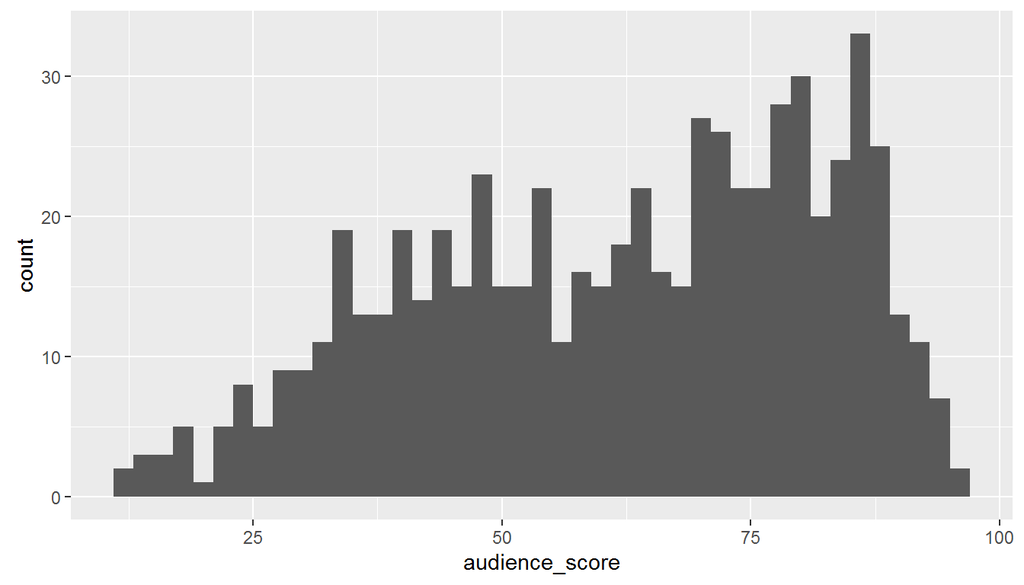

```r
ggplot(movies, aes(audience_score)) +
     geom_histogram(binwidth = 2)
```

Okay it has such strong skewness of the acore distribution. but I want nearly perfect normal distribution for further inference.

**Apply Sampling Distribution**

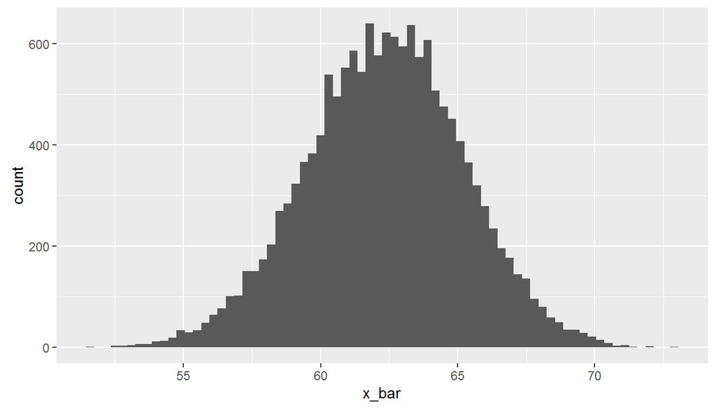

```r
sample_means50 <- movies %>%
     rep_sample_n(size = 50, reps = 15000, replace = TRUE) %>%
     summarise(x_bar = mean(audience_score))
ggplot(data = sample_means50, aes(x = x_bar)) +
  geom_histogram(binwidth = .3)
```

Okay now we can build 95% CI with Sampling Distribution.

**Building 95% CI with Sampling Distribution**

```r
z_star_95 <- qnorm(.975)
z_star_95
```

```
## [1] 1.959964
```

```r
n <- 60
ci <- movies %>%
     rep_sample_n(size = 60, reps = 50, replace = TRUE) %>%
     summarise(lower = mean(audience_score) - z_star_95 * (sd(audience_score) / sqrt(n)),
               upper = mean(audience_score) + z_star_95 * (sd(audience_score) / sqrt(n)))
ci %>%
  slice(1:5)
```

```
## Source: local data frame [5 x 3]
##
##   replicate    lower    upper
##       (int)    (dbl)    (dbl)
## 1         1 62.17768 70.98898
## 2         2 56.26749 66.16585
## 3         3 57.20518 68.39482
## 4         4 58.82019 68.87981
## 5         5 61.03965 70.06035
```

**Plotting Confidence Interval**

```r
inference(y = audience_score, data = movies, statistic = "mean", type = "ci",
          conf_level = 0.95, method = "theoretical", order = c("Yes","No"))
```

```
## Single numerical variable
## n = 651, y-bar = 62.3625, s = 20.2226
## 95% CI: (60.8062 , 63.9189)
```

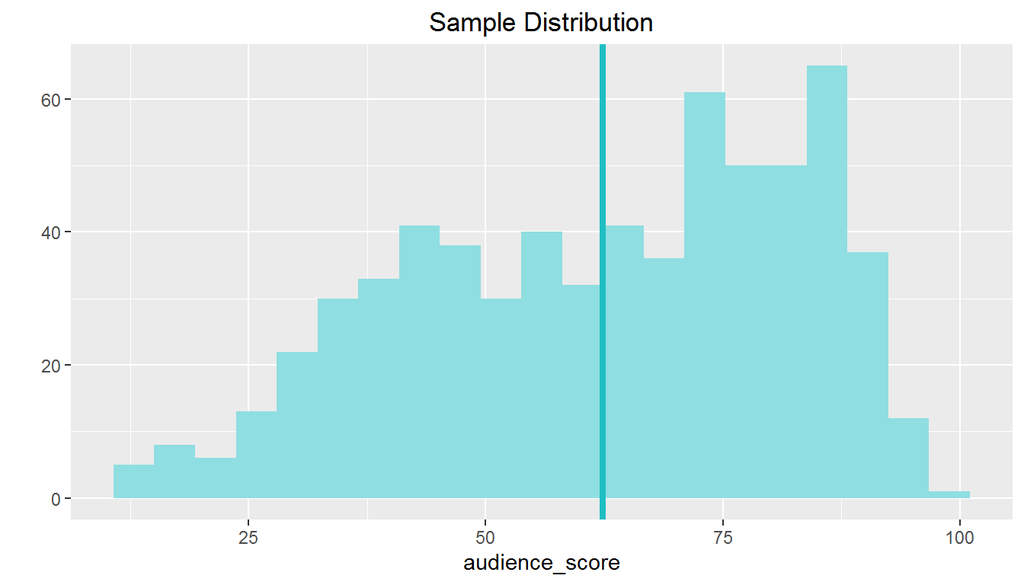

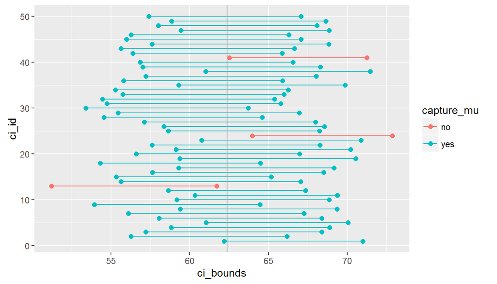

```r
# true population mean
params <- movies %>%
     summarise(mu = mean(audience_score))

ci <- ci %>%
     mutate(capture_mu = ifelse(lower < params$mu & upper > params$mu, "yes", "no"))

ci_data <- data.frame(ci_id = c(1:50, 1:50),
                      ci_bounds = c(ci$lower, ci$upper),
                      capture_mu = c(ci$capture, ci$capture))

ggplot(data = ci_data, aes(x = ci_bounds, y = ci_id, group = ci_id, color = capture_mu)) +
     geom_point(size = 2) +  # add points at the ends, size = 2
     geom_line() +           # connect with lines
     geom_vline(xintercept = params$mu, color = "darkgray") # draw vertical line
```

Interpretation: The population mean of audience score lies between these two bounds of 60.8062 , 63.9189, since 95% of the time confidence intervals contain the true mean.

### Research quesion:

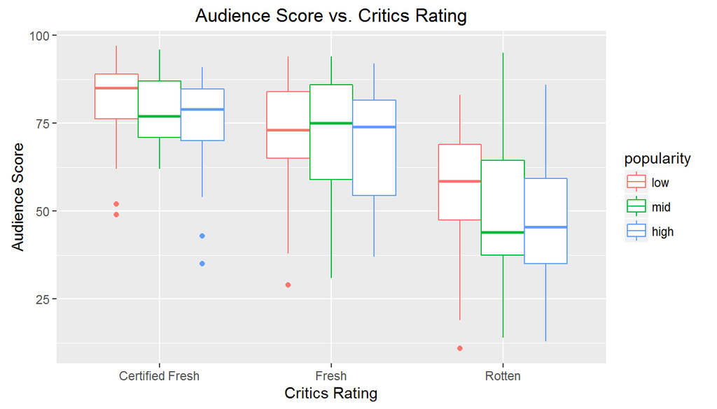

```r
ggplot(movies, aes(critics_rating, audience_score)) +
     geom_boxplot(aes(colour=popularity)) +
     labs(title = "Audience Score vs. Critics Rating") +
     xlab("Critics Rating") +
     ylab("Audience Score")
```

```r
movies %>%
     group_by(critics_rating) %>%
     summarise(mean(audience_score))
```

```
## Source: local data frame [3 x 2]
##
##    critics_rating mean(audience_score)
##            (fctr)                (dbl)
## 1 Certified Fresh             79.37037
## 2           Fresh             69.97129
## 3          Rotten             49.70358
```

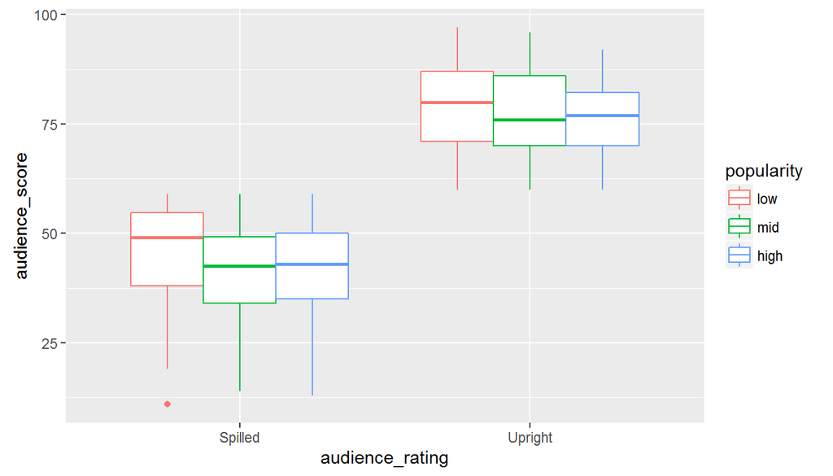

```r
ggplot(movies, aes(audience_rating, audience_score)) +
     geom_boxplot(aes(colour=popularity))
```

```r
movies %>%
     group_by(audience_rating) %>%
     summarise(mean(audience_score))
```

```
## Source: local data frame [2 x 2]
##
##   audience_rating mean(audience_score)
##            (fctr)                (dbl)
## 1         Spilled             41.93455
## 2         Upright             77.30319
```

**Audience Score vs Critices Rating**  
$H_0: \mu_{1} = \mu_{2} = \mu_{3} ... = \mu_{k}$; $H_A:$ At least one mean is different

```r
model <- aov(audience_score ~ critics_rating, movies)
anova(model)
```

```
## Analysis of Variance Table
##
## Response: audience_score
##                 Df Sum Sq Mean Sq F value    Pr(>F)
## critics_rating   2 100347   50174  196.48 < 2.2e-16 ***
## Residuals      648 165473     255
## ---
## Signif. codes:  0 '***' 0.001 '**' 0.01 '*' 0.05 '.' 0.1 ' ' 1
```

```r
result <- 100347/(100347+165473)
result
```

```
## [1] 0.3774998
```

```r
# We need to caluclate new p-value for ANOVA
k <- length(unique(movies$critics_rating))
k <- k*(k-1)/2
alpha <- .05
alpha_adj <- alpha/k
alpha_adj
```

```
## [1] 0.01666667
```

**Audience Score vs Audience Rating**  
$H_0: \mu_{Spilled} = \mu_{Upright}$; $H_A: \mu_{Spilled} \ne \mu_{Upright}$

```r
# Confidence Interval with function (Mean : Catagorical vs Quantative)
inference(y = audience_score, x = audience_rating, data = movies, statistic = "mean", type = "ci",
          method = "theoretical", order = c("Spilled","Upright"))
```

```
## Response variable: numerical, Explanatory variable: categorical (2 levels)
## n_Spilled = 275, y_bar_Spilled = 41.9345, s_Spilled = 11.217
## n_Upright = 376, y_bar_Upright = 77.3032, s_Upright = 9.3317
## 95% CI (Spilled - Upright): (-37.0029 , -33.7344)
```

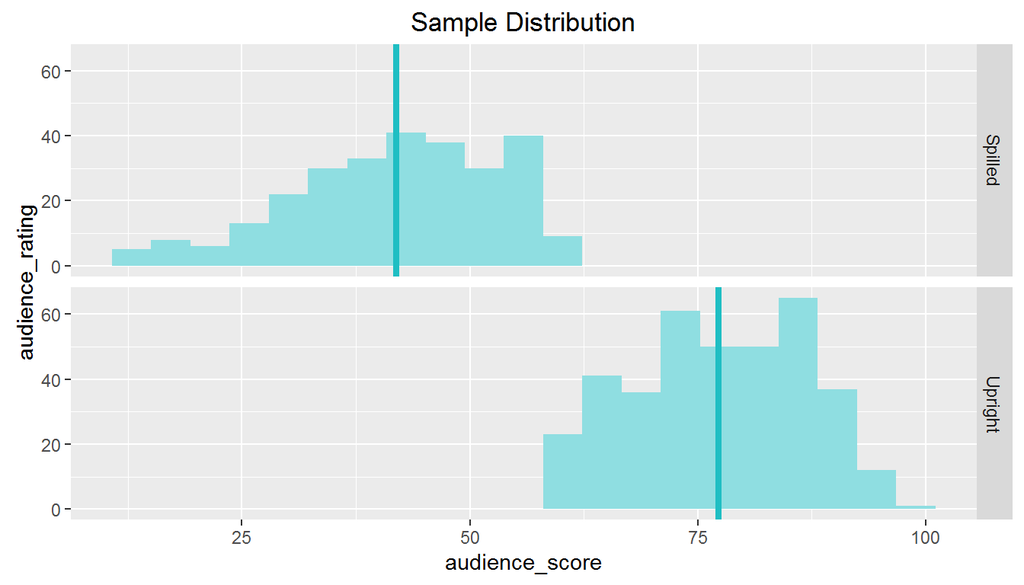

```r
# Hypothesis Test with functions (Mean : Catagorical vs Quantative)
inference(y = audience_score, x = audience_rating, data = movies, statistic = "mean", type = "ht", null = 0,
          alternative = "twosided", method = "theoretical")
```

```
## Response variable: numerical
## Explanatory variable: categorical (2 levels)
## n_Spilled = 275, y_bar_Spilled = 41.9345, s_Spilled = 11.217
## n_Upright = 376, y_bar_Upright = 77.3032, s_Upright = 9.3317
## H0: mu_Spilled =  mu_Upright
## HA: mu_Spilled != mu_Upright
## t = -42.6058, df = 274
## p_value = < 0.0001
```

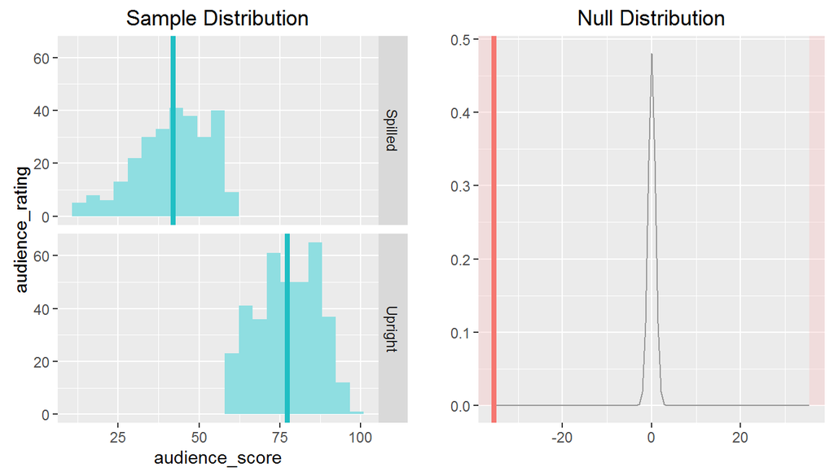

Interpretation:  
The population mean difference of two groups lies btween there two bounds of -37 and -33, since 95% of the time confidence intervals contain the tru means. Since the p-val is less than .05 we will reject the null hypothesis and accept the alternative hypothesis that aduience rating is effecting on aduience score.

```r
# Anova
model <- aov(audience_score ~ audience_rating, movies)
anova(model)
```

```
## Analysis of Variance Table
##
## Response: audience_score
##                  Df Sum Sq Mean Sq F value    Pr(>F)
## audience_rating   1 198690  198690  1920.9 < 2.2e-16 ***
## Residuals       649  67130     103
## ---
## Signif. codes:  0 '***' 0.001 '**' 0.01 '*' 0.05 '.' 0.1 ' ' 1
```

```r
result <- 198690/(198690+67130)
result
```

```
## [1] 0.7474607
```

```r
# We need to caluclate new p-value for ANOVA
k <- length(unique(movies$critics_rating))
k <- k*(k-1)/2
alpha <- .05
alpha_adj <- alpha/k
alpha_adj
```

```
## [1] 0.01666667
```

## Part 4: Modeling

```r
# Build base model
mdl_lm0 <- lm(audience_score ~ ., movies)
sum_lm0 <- summary(mdl_lm0)
sum_lm0
```

```
##
## Call:
## lm(formula = audience_score ~ ., data = movies)
##
## Residuals:
##      Min       1Q   Median       3Q      Max
## -19.4906  -2.8766   0.0451   2.9463  17.5860
##
## Coefficients:
##                                  Estimate Std. Error t value Pr(>|t|)
## (Intercept)                     2.856e+02  1.057e+02   2.702  0.00708 **
## genreAnimation                  2.726e+00  2.214e+00   1.231  0.21884
## genreArt House & International -1.318e+00  1.724e+00  -0.764  0.44495
## genreComedy                     7.173e-01  9.426e-01   0.761  0.44698
## genreDocumentary               -2.257e+00  1.397e+00  -1.616  0.10670
## genreDrama                     -7.512e-01  8.424e-01  -0.892  0.37288
## genreHorror                    -5.493e-01  1.400e+00  -0.392  0.69484
## genreMusical & Performing Arts -4.663e-01  1.847e+00  -0.253  0.80072
## genreMystery & Suspense        -1.631e+00  1.058e+00  -1.542  0.12370
## genreOther                     -4.460e-01  1.593e+00  -0.280  0.77962
## genreScience Fiction & Fantasy  8.348e-01  1.991e+00   0.419  0.67521
## mpaa_ratingNC-17                5.667e-01  4.221e+00   0.134  0.89324
## mpaa_ratingPG                   1.087e+00  1.540e+00   0.706  0.48042
## mpaa_ratingPG-13                1.068e+00  1.623e+00   0.658  0.51081
## mpaa_ratingR                    5.979e-01  1.557e+00   0.384  0.70108
## mpaa_ratingUnrated              1.216e+00  1.803e+00   0.675  0.50023
## critics_ratingFresh             2.290e-01  7.229e-01   0.317  0.75156
## critics_ratingRotten            1.370e+00  1.150e+00   1.192  0.23389
## audience_ratingUpright          2.876e+00  1.134e+00   2.537  0.01144 *
## best_pic_nomyes                 6.475e-01  1.485e+00   0.436  0.66295
## best_pic_winyes                -7.831e-01  2.583e+00  -0.303  0.76186
## best_actor_winyes              -2.682e-01  6.653e-01  -0.403  0.68696
## best_actress_winyes            -6.332e-01  7.350e-01  -0.861  0.38931
## best_dir_winyes                -5.324e-01  9.651e-01  -0.552  0.58140
## top200_boxyes                  -2.178e-01  1.566e+00  -0.139  0.88948
## popularitymid                   1.197e+00  8.928e-01   1.341  0.18039
## popularityhigh                  8.167e-01  7.168e-01   1.139  0.25498
## runtime                        -2.269e-02  1.418e-02  -1.600  0.11019
## thtr_rel_year                  -1.520e-01  5.257e-02  -2.892  0.00396 **
## thtr_rel_month                 -8.537e-02  6.478e-02  -1.318  0.18806
## imdb_rating                     5.782e+00  4.433e-01  13.044  < 2e-16 ***
## imdb_num_votes                  2.760e-06  3.047e-06   0.906  0.36540
## critics_score                  -5.459e-03  2.042e-02  -0.267  0.78933
## date_dff                       -4.779e-04  1.804e-04  -2.650  0.00826 **
## mu_all                          7.069e-01  3.913e-02  18.066  < 2e-16 ***
## ---
## Signif. codes:  0 '***' 0.001 '**' 0.01 '*' 0.05 '.' 0.1 ' ' 1
##
## Residual standard error: 5.531 on 616 degrees of freedom
## Multiple R-squared:  0.9291, Adjusted R-squared:  0.9252
## F-statistic: 237.4 on 34 and 616 DF,  p-value: < 2.2e-16
```

```r
sum_lm0$adj.r.squared
```

```
## [1] 0.925189
```

Wow we already have close to 1 R squared, this base model is already good. However, we need to explor a bit more and see if we can improve this model.  
First I’m going remove genre since it has such high p-value.

```r
mdl_lm1 <- lm(audience_score ~ . -genre, movies)
sum_lm1 <- summary(mdl_lm1)
sum_lm1
```

```
##
## Call:
## lm(formula = audience_score ~ . - genre, data = movies)
##
## Residuals:
##      Min       1Q   Median       3Q      Max
## -23.2442  -4.5552   0.2674   4.3063  25.3521
##
## Coefficients:
##                          Estimate Std. Error t value Pr(>|t|)
## (Intercept)             3.419e+02  1.302e+02   2.625  0.00886 **
## mpaa_ratingNC-17       -2.131e+00  5.182e+00  -0.411  0.68102
## mpaa_ratingPG          -6.304e-01  1.731e+00  -0.364  0.71585
## mpaa_ratingPG-13       -1.593e+00  1.787e+00  -0.891  0.37303
## mpaa_ratingR           -2.372e+00  1.686e+00  -1.407  0.15993
## mpaa_ratingUnrated     -2.704e-01  2.019e+00  -0.134  0.89347
## critics_ratingFresh    -4.340e-01  9.094e-01  -0.477  0.63333
## critics_ratingRotten   -1.064e+00  1.419e+00  -0.750  0.45374
## audience_ratingUpright  2.014e+01  7.899e-01  25.501  < 2e-16 ***
## best_pic_nomyes         3.960e+00  1.830e+00   2.165  0.03080 *
## best_pic_winyes        -2.669e+00  3.200e+00  -0.834  0.40462
## best_actor_winyes      -3.050e-01  8.227e-01  -0.371  0.71098
## best_actress_winyes    -1.603e+00  9.026e-01  -1.776  0.07628 .
## best_dir_winyes         1.316e-01  1.204e+00   0.109  0.91300
## top200_boxyes          -1.146e+00  1.943e+00  -0.590  0.55563
## popularitymid          -5.934e-01  1.058e+00  -0.561  0.57523
## popularityhigh         -1.617e-01  8.806e-01  -0.184  0.85439
## runtime                -3.042e-02  1.706e-02  -1.783  0.07508 .
## thtr_rel_year          -1.721e-01  6.478e-02  -2.656  0.00810 **
## thtr_rel_month         -1.382e-01  7.993e-02  -1.728  0.08439 .
## imdb_rating             9.205e+00  4.725e-01  19.484  < 2e-16 ***
## imdb_num_votes          3.761e-06  3.729e-06   1.009  0.31356
## critics_score           9.724e-03  2.524e-02   0.385  0.70020
## date_dff               -5.662e-04  2.517e-04  -2.249  0.02485 *
## mu_all                  1.101e-04  2.010e-04   0.548  0.58419
## ---
## Signif. codes:  0 '***' 0.001 '**' 0.01 '*' 0.05 '.' 0.1 ' ' 1
##
## Residual standard error: 6.895 on 626 degrees of freedom
## Multiple R-squared:  0.888,  Adjusted R-squared:  0.8837
## F-statistic: 206.9 on 24 and 626 DF,  p-value: < 2.2e-16
```

```r
sum_lm1$adj.r.squared
```

```
## [1] 0.8837397
```

By removing genre, R squared reduced, so we are going to keep ganre in the model model.  
And now I’m going to remove award variables with same reason.

```r
mdl_lm3 <- lm(audience_score ~ . -best_pic_nom -best_pic_win -best_actor_win -best_actress_win -best_dir_win, movies)
sum_lm3 <- summary(mdl_lm3)
sum_lm3
```

```
##
## Call:
## lm(formula = audience_score ~ . - best_pic_nom - best_pic_win -
##     best_actor_win - best_actress_win - best_dir_win, data = movies)
##
## Residuals:
##      Min       1Q   Median       3Q      Max
## -22.7176  -4.6261   0.4347   4.1006  24.3021
##
## Coefficients:
##                                  Estimate Std. Error t value Pr(>|t|)
## (Intercept)                     3.103e+02  1.300e+02   2.388   0.0173 *
## genreAnimation                  3.607e+00  2.754e+00   1.310   0.1908
## genreArt House & International -1.640e+00  2.129e+00  -0.770   0.4416
## genreComedy                     1.655e+00  1.158e+00   1.429   0.1534
## genreDocumentary                1.533e+00  1.719e+00   0.892   0.3728
## genreDrama                     -1.403e-01  1.029e+00  -0.136   0.8916
## genreHorror                    -1.602e+00  1.733e+00  -0.925   0.3555
## genreMusical & Performing Arts  3.865e+00  2.267e+00   1.705   0.0887 .
## genreMystery & Suspense        -2.800e+00  1.292e+00  -2.168   0.0305 *
## genreOther                     -1.673e-01  1.962e+00  -0.085   0.9321
## genreScience Fiction & Fantasy -4.422e-01  2.464e+00  -0.179   0.8576
## mpaa_ratingNC-17               -1.147e+00  5.213e+00  -0.220   0.8259
## mpaa_ratingPG                   1.600e-01  1.903e+00   0.084   0.9330
## mpaa_ratingPG-13               -4.459e-01  2.023e+00  -0.220   0.8256
## mpaa_ratingR                   -7.094e-01  1.939e+00  -0.366   0.7145
## mpaa_ratingUnrated              7.041e-01  2.264e+00   0.311   0.7559
## critics_ratingFresh            -3.262e-01  8.975e-01  -0.363   0.7164
## critics_ratingRotten           -1.147e+00  1.413e+00  -0.812   0.4169
## audience_ratingUpright          1.972e+01  7.987e-01  24.685   <2e-16 ***
## top200_boxyes                  -1.176e+00  1.936e+00  -0.607   0.5439
## popularitymid                  -1.357e+00  1.119e+00  -1.212   0.2260
## popularityhigh                 -5.349e-01  8.913e-01  -0.600   0.5487
## runtime                        -2.546e-02  1.692e-02  -1.504   0.1330
## thtr_rel_year                  -1.574e-01  6.461e-02  -2.436   0.0151 *
## thtr_rel_month                 -1.506e-01  7.926e-02  -1.900   0.0579 .
## imdb_rating                     9.323e+00  4.920e-01  18.947   <2e-16 ***
## imdb_num_votes                  4.375e-06  3.666e-06   1.193   0.2332
## critics_score                   6.317e-03  2.524e-02   0.250   0.8024
## date_dff                       -5.267e-04  2.498e-04  -2.108   0.0354 *
## mu_all                          2.358e-04  2.027e-04   1.163   0.2452
## ---
## Signif. codes:  0 '***' 0.001 '**' 0.01 '*' 0.05 '.' 0.1 ' ' 1
##
## Residual standard error: 6.846 on 621 degrees of freedom
## Multiple R-squared:  0.8905, Adjusted R-squared:  0.8854
## F-statistic: 174.2 on 29 and 621 DF,  p-value: < 2.2e-16
```

```r
sum_lm3$adj.r.squared
```

```
## [1] 0.8853918
```

```r
mdl_lm4 <- lm(audience_score ~ . -best_pic_nom -best_pic_win -best_actor_win -best_actress_win -best_dir_win -mpaa_rating, movies)
sum_lm4 <- summary(mdl_lm4)
sum_lm4
```

```
##
## Call:
## lm(formula = audience_score ~ . - best_pic_nom - best_pic_win -
##     best_actor_win - best_actress_win - best_dir_win - mpaa_rating,
##     data = movies)
##
## Residuals:
##      Min       1Q   Median       3Q      Max
## -21.9776  -4.7754   0.4579   4.1864  24.0204
##
## Coefficients:
##                                  Estimate Std. Error t value Pr(>|t|)
## (Intercept)                     2.855e+02  1.275e+02   2.239   0.0255 *
## genreAnimation                  3.967e+00  2.482e+00   1.599   0.1104
## genreArt House & International -1.637e+00  2.096e+00  -0.781   0.4350
## genreComedy                     1.584e+00  1.146e+00   1.382   0.1675
## genreDocumentary                2.020e+00  1.634e+00   1.236   0.2168
## genreDrama                     -3.503e-01  1.009e+00  -0.347   0.7285
## genreHorror                    -1.850e+00  1.685e+00  -1.098   0.2727
## genreMusical & Performing Arts  3.835e+00  2.257e+00   1.699   0.0898 .
## genreMystery & Suspense        -3.095e+00  1.264e+00  -2.448   0.0146 *
## genreOther                     -1.386e-01  1.949e+00  -0.071   0.9433
## genreScience Fiction & Fantasy -4.986e-01  2.455e+00  -0.203   0.8391
## critics_ratingFresh            -2.925e-01  8.900e-01  -0.329   0.7426
## critics_ratingRotten           -1.018e+00  1.404e+00  -0.725   0.4686
## audience_ratingUpright          1.975e+01  7.939e-01  24.884   <2e-16 ***
## top200_boxyes                  -9.152e-01  1.913e+00  -0.478   0.6325
## popularitymid                  -1.295e+00  1.099e+00  -1.178   0.2391
## popularityhigh                 -4.912e-01  8.835e-01  -0.556   0.5784
## runtime                        -2.455e-02  1.646e-02  -1.492   0.1363
## thtr_rel_year                  -1.453e-01  6.338e-02  -2.293   0.0222 *
## thtr_rel_month                 -1.499e-01  7.865e-02  -1.905   0.0572 .
## imdb_rating                     9.306e+00  4.896e-01  19.006   <2e-16 ***
## imdb_num_votes                  3.965e-06  3.642e-06   1.089   0.2768
## critics_score                   9.653e-03  2.502e-02   0.386   0.6998
## date_dff                       -4.926e-04  2.472e-04  -1.992   0.0468 *
## mu_all                          2.575e-04  1.932e-04   1.333   0.1831
## ---
## Signif. codes:  0 '***' 0.001 '**' 0.01 '*' 0.05 '.' 0.1 ' ' 1
##
## Residual standard error: 6.83 on 626 degrees of freedom
## Multiple R-squared:  0.8902, Adjusted R-squared:  0.8859
## F-statistic: 211.4 on 24 and 626 DF,  p-value: < 2.2e-16
```

```r
sum_lm4$adj.r.squared
```

```
## [1] 0.8859477
```

Again we gained a bit more R squared value. We will continue this process until we do not have any more R squared gain.

```r
mdl_lm5 <- lm(audience_score ~ . -best_pic_nom -best_pic_win -best_actor_win
              -best_actress_win -best_dir_win -mpaa_rating -top200_box -critics_score, movies)
sum_lm5 <- summary(mdl_lm5)
sum_lm5$adj.r.squared
```

```
## [1] 0.8862442
```

```r
mdl_lm6 <- lm(audience_score ~ . -best_pic_nom -best_pic_win -best_actor_win
              -best_actress_win -best_dir_win -mpaa_rating -top200_box -critics_score -popularity, movies)
sum_lm6 <- summary(mdl_lm6)
sum_lm6$adj.r.squared
```

```
## [1] 0.8863315
```

Okay we finally found the right combination of predictors with has R squared of .8863 I’m gonig to add the cluster variables to see if it improves a bit

```r
setwd("F:/specialization/22-Master Statistics with R (Duke University)/data")
movies <- readRDS("movies04_yesCluster.rds")
mdl_lm7 <- lm(audience_score ~ ., movies)
sum_lm7 <- summary(mdl_lm7)
sum_lm7$adj.r.squared
```

```
## [1] 0.886351
```

Okay, so cluster variables does not do much, we are going back to previous dataset.

### Model Dignostic

**Nearly Normal Residuals with mean 0**

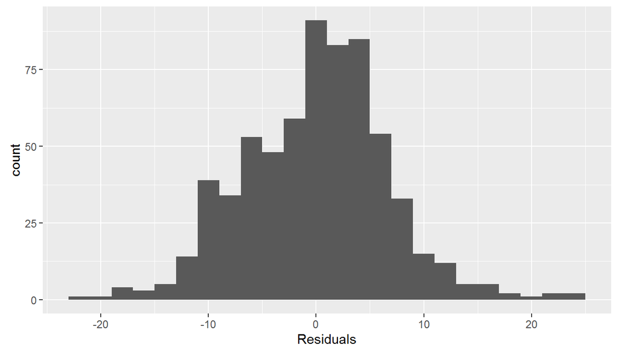

```r
# Nearly normal residuals: Residuals are right skewed, but the sample size is large, so this may not be an important violation of conditions.
setwd("F:/specialization/22-Master Statistics with R (Duke University)/data")
movies <- readRDS("movies02.rds")
mdl_lm6 <- lm(audience_score ~ ., movies)

ggplot(mdl_lm6, aes(.resid)) +
     geom_histogram(binwidth = 2) +
     xlab("Residuals")
```

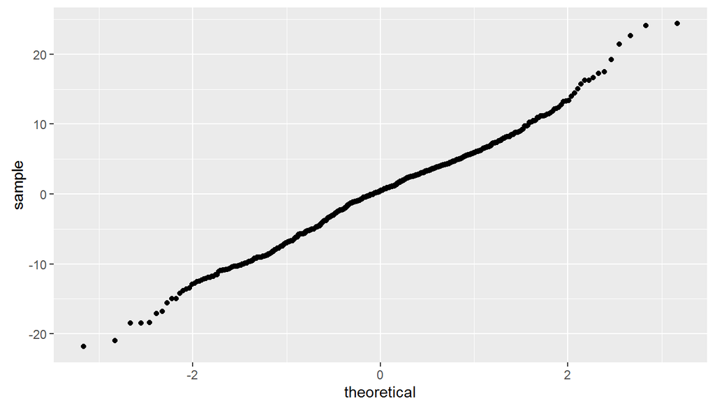

```r
ggplot(mdl_lm6, aes(sample = .resid)) +
     stat_qq()
```

**Constan Variability of Residuals**

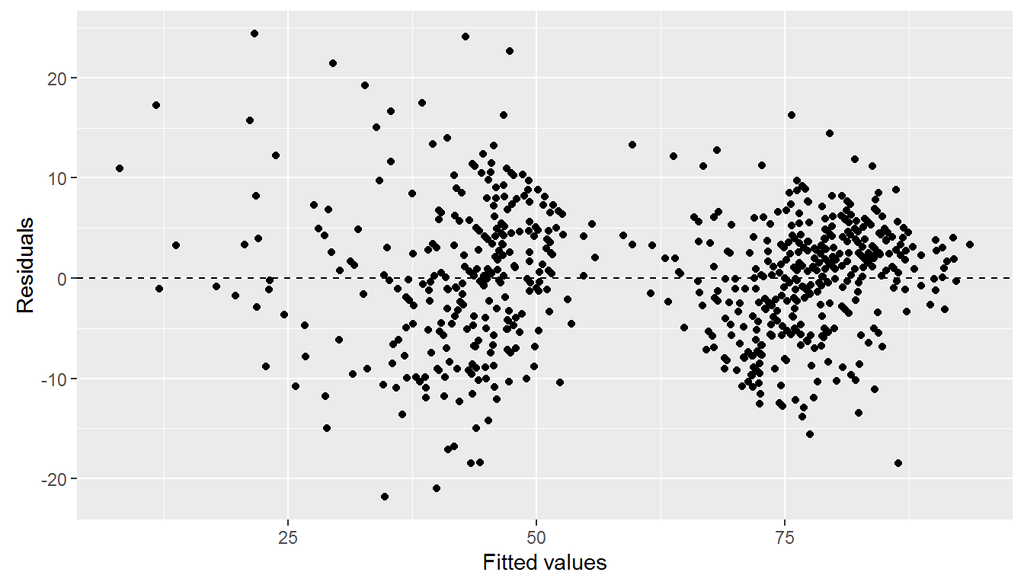

```r
# Linear association: The residuals plot shows a random scatter.
# Constant variance of residuals: No fan shape in residuals plot.
ggplot(mdl_lm6, aes(.fitted, .resid)) +
     geom_point() +
     geom_hline(yintercept = 0, linetype = "dashed") +
     xlab("Fitted values") +
     ylab("Residuals")
```

The model passes all the diagnostic tests.

**Correlation plot**

```r
library(GGally)
library(psych)
```

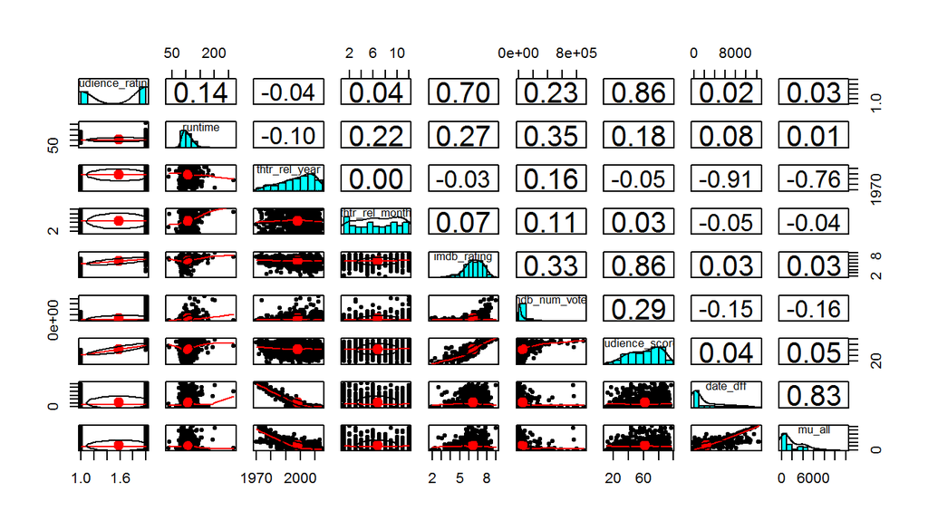

```r
pairs.panels(movies[,3:ncol(movies)])
```

## Part 5: Prediction

```r
setwd("F:/specialization/22-Master Statistics with R (Duke University)/data")
movies <- readRDS("movies02.rds")
str(movies)
```

```
## 'data.frame':    651 obs. of  11 variables:
##  $ genre          : Factor w/ 11 levels "Action & Adventure",..: 1 1 1 1 1 1 1 1 1 1 ...
##  $ critics_rating : Factor w/ 3 levels "Certified Fresh",..: 1 2 2 3 3 1 2 2 3 3 ...
##  $ audience_rating: Factor w/ 2 levels "Spilled","Upright": 2 1 2 1 2 2 1 1 1 1 ...
##  $ runtime        : num  90 113 118 103 83 120 98 138 99 83 ...
##  $ thtr_rel_year  : num  1992 1977 1979 1996 1973 ...
##  $ thtr_rel_month : num  11 1 10 11 11 6 7 6 1 5 ...
##  $ imdb_rating    : num  8 6.3 7.4 5.6 7.6 7 6 5.7 4.2 3.5 ...
##  $ imdb_num_votes : int  246907 4687 8544 70209 78862 201787 109633 204042 43268 10055 ...
##  $ audience_score : num  92 55 83 40 81 71 49 29 33 30 ...
##  $ date_dff       : num  4346 8592 6538 508 9735 ...
##  $ mu_all         : num  4346 8592 6538 508 9735 ...
```

I’m going to exclude few movies before I build the model so that i can predict the score for that movie which is not included in the sample.

```r
rand <- sample(nrow(movies), 5)
test <- movies[rand, ]
train <- movies[-rand, ]

mdl_lm <- lm(audience_score ~ ., train)
summary(mdl_lm)
```

```
##
## Call:
## lm(formula = audience_score ~ ., data = train)
##
## Residuals:
##      Min       1Q   Median       3Q      Max
## -21.8666  -4.7026   0.4622   4.1496  24.3497
##
## Coefficients:
##                                  Estimate Std. Error t value Pr(>|t|)
## (Intercept)                     3.123e+02  1.276e+02   2.448   0.0146 *
## genreAnimation                  3.821e+00  2.460e+00   1.553   0.1208
## genreArt House & International -2.040e+00  2.049e+00  -0.996   0.3199
## genreComedy                     1.516e+00  1.128e+00   1.345   0.1792
## genreDocumentary                1.292e+00  1.482e+00   0.872   0.3833
## genreDrama                     -5.519e-01  9.791e-01  -0.564   0.5732
## genreHorror                    -1.792e+00  1.673e+00  -1.071   0.2846
## genreMusical & Performing Arts  3.483e+00  2.215e+00   1.572   0.1164
## genreMystery & Suspense        -3.131e+00  1.252e+00  -2.501   0.0126 *
## genreOther                     -2.690e-01  1.931e+00  -0.139   0.8892
## genreScience Fiction & Fantasy -5.187e-01  2.442e+00  -0.212   0.8318
## critics_ratingFresh            -4.288e-01  8.561e-01  -0.501   0.6166
## critics_ratingRotten           -1.462e+00  9.237e-01  -1.583   0.1140
## audience_ratingUpright          1.984e+01  7.902e-01  25.109   <2e-16 ***
## runtime                        -2.205e-02  1.637e-02  -1.347   0.1784
## thtr_rel_year                  -1.590e-01  6.343e-02  -2.507   0.0124 *
## thtr_rel_month                 -1.571e-01  7.845e-02  -2.002   0.0457 *
## imdb_rating                     9.440e+00  4.248e-01  22.225   <2e-16 ***
## imdb_num_votes                  4.722e-06  3.047e-06   1.550   0.1217
## date_dff                       -5.062e-04  2.466e-04  -2.052   0.0406 *
## mu_all                          1.683e-04  1.898e-04   0.887   0.3756
## ---
## Signif. codes:  0 '***' 0.001 '**' 0.01 '*' 0.05 '.' 0.1 ' ' 1
##
## Residual standard error: 6.808 on 625 degrees of freedom
## Multiple R-squared:  0.8903, Adjusted R-squared:  0.8868
## F-statistic: 253.6 on 20 and 625 DF,  p-value: < 2.2e-16
```

```r
y_hat <- round(predict(mdl_lm, test), 0)
y <- test$audience_score
total_r_sq <- sum((y - y_hat)^2)

data.frame("Actual y" = y, "Predicted y" = y_hat)
```

```
##     Actual.y Predicted.y
## 329       55          43
## 267       31          40
## 403       44          48
## 400       59          50
## 490       43          46
```

```r
print(paste0("R Squared : ", total_r_sq))
```

```
## [1] "R Squared : 331"
```